# Prosper Loan Data Exploration

### by Amisha Rastogi

## Effect of various factors on loan status as well as the loan characterstics on Borrower's APR.

### Investigation Overview

In this investigation, I wanted to look at the factors or features that could help the loan applicant and characterstics of loans that be used to predict borrower APR. The main focus was on the some of the variables like 'Term' , 'LoanStatus', 'ProsperScore', 'EmploymentStatus', 'BorrowerHomeowner', 'StatedMonthlyIncome', 'LoanOriginalAmount'.

### Dataset Overview

This ProsperLoan data set contains 113,937 loans with 81 variables on each loan, including loan amount, borrower rate (or interest rate), current loan status, borrower income, and many others.For simplicity of the visualization I have looked at only few variables as the project objective itself says to focus on only few variables which consist of 76762 rows and 16 columns.

### The Distribution of Borrower APR:

#### The BorrowerAPR is the annual cost of a loan to a borrower. Unlike an interest rate, it includes other charges or fees to reflect the total cost of the loan.

From the visualization we can easily depict that it is multimodal having a sharp peak between 0.35 and 0.38, further we can observe that there is peak (small) at 0.1 as well as at 0.3.

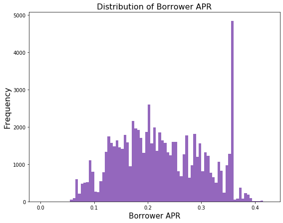

```python
# plotting borrowerapr
plt.figure(figsize = [9, 7])
bins_edges = np.arange(0, df['borrowerapr'].max()+0.005, 0.005)
plt.hist(data =df, x = 'borrowerapr',bins = bins_edges, color = base_color);
plt.xlabel('Borrower APR', fontsize = 15);
plt.ylabel('Frequency', fontsize = 16);
plt.title('Distribution of Borrower APR', fontsize = 16);
```

### Distribution of Prosper Rating:

#### ProsperRating is an ordinal categorical variable defined by Prosper using historical data, with the following values from higher to lower ('AA', 'A', 'B', 'C', 'D', 'E', 'HR'), ratings have almost normal distribution in data set centered at 'C' which is having the maximum count the highest 'AA' and the lowest 'HR' ratings have the lowest counts

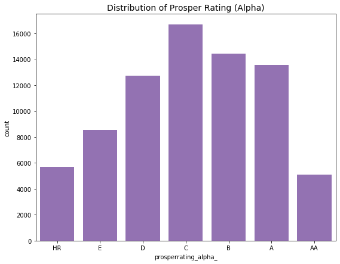

```python
plt.figure(figsize = [9, 7])
sb.countplot(data = df,x = 'prosperrating_alpha_', color = base_color, order= order_1)
plt.title('Distribution of Prosper Rating (Alpha)', fontsize = 14);
```

### Distribution of stated monthly income:

#### StatedMonthlyIncome is the monthly income the borrower stated at the time when the listing was created.

#### The histogram plot of the original data is highly right skewed. To find the outliers that shows maximum data towards the left, by using describe function I found out that the maximum value is 483333 dollars, which is likely to be an error as we can also see that median is around 5000 dollars.By removing the outliers I have depicted it till 30000 dollars having a peak at 5000.

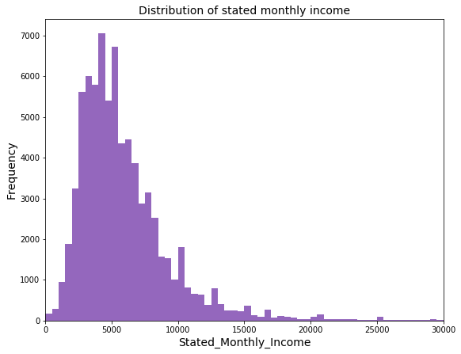

```python
# distribution of stated monthly income:
plt.figure(figsize = [9, 7])
bins_2 = np.arange(0 , 50000, 500)
plt.hist(data = df, x = 'statedmonthlyincome', bins =bins_2, color = base_color);
plt.xlabel('Stated_Monthly_Income',fontsize = 14)
plt.ylabel('Frequency', fontsize = 14)
plt.title('Distribution of stated monthly income', fontsize =14)
plt.xlim(0,30000);
```

### Distribuition of Listing Category:

#### ListingCategory is the category of listing. Prosper uses numeric values to represent the categories.

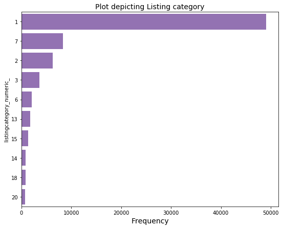

```python
# plotting listing categories:
plt.figure(figsize = [9, 7])
t2 = df['listingcategory_numeric_'].value_counts().head(10)
t2_order = t2.index
sb.countplot(data = df, y = 'listingcategory_numeric_',color =base_color,order = t2_order)
plt.title('Plot depicting Listing category', fontsize = 14)
plt.xlabel('Frequency', fontsize = 14);
```

### Factors Affecting Borrower APR:

#### From the following plots we can depict how Borrower APR depends on Term, Prosper Rating(Alpha) and Debt to Income Ratio. Interestingly we can observe thatThe borrower APR decreases with the better rating. Borrowers with the best Prosper ratings have the lowest APR. It means that the Prosper rating has a strong effect on borrower APR.

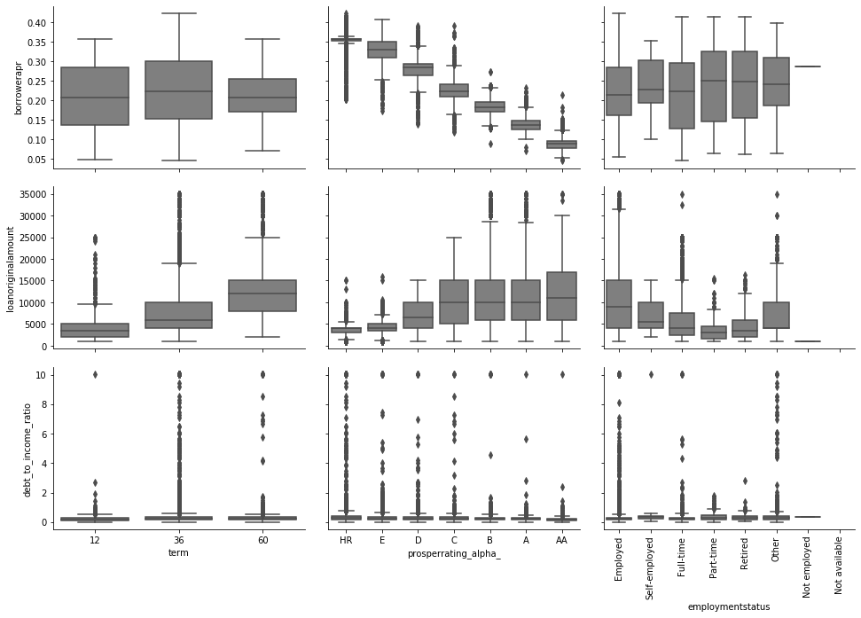

```python
#from lesson of bivariate plots
def box_grid(x, y, **kwargs):
    """ Quick hack for creating box plots with seaborn's PairGrid. """
    sb.boxplot(x, y, color = base_color_1)

plt.figure(figsize = [10, 10])
g = sb.PairGrid(data = df, y_vars = ['borrowerapr','loanoriginalamount','debt_to_income_ratio'],
                x_vars = ['term','prosperrating_alpha_','employmentstatus'], height = 3, aspect = 1.5)
plt.xticks(rotation=90);
g.map(box_grid);
```

### Relationship between Categorical Variables and there effect on each other:

#### Through the observations of the above plot we can say that prosper rating 'C' has maximum number of loans of 60 months term, further we can observe that over 9000 borrowers of 'A' category have 36 months of loan.

#### From the second plot we can depict that Maximum borrowers who are employed hav taken loans of 36 as well as 60 months.

##### From the third plot we observe that employed category people maximum of them belong to either 'C' or 'B' prosper rating.

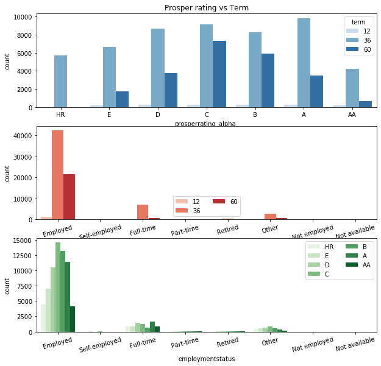

```python
plt.figure(figsize = [10, 13])

# subplot 1: Prosper rating vs term
plt.subplot(4, 1, 1)
sb.countplot(data = df, x = 'prosperrating_alpha_', hue = 'term', palette = 'Blues')
plt.title('Prosper rating vs Term')

# subplot 2: employment status vs. term
ax = plt.subplot(4, 1, 2)
sb.countplot(data = df, x = 'employmentstatus', hue = 'term', palette = 'Reds')
plt.xticks(rotation = 15)
ax.legend(ncol = 2)


# subplot 3: Prosper rating vs. employment status
ax = plt.subplot(4, 1, 3)
sb.countplot(data = df, x ='employmentstatus', hue = 'prosperrating_alpha_', palette = 'Greens')
ax.legend(loc = 1, ncol = 2); # re-arrange legend to remove overlapping
plt.xticks(rotation = 15);
```

### Relationship between Borrower APR vs Rating and Term:

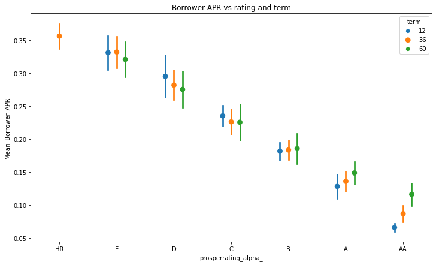

```python
plt.figure(figsize = [12, 7])
ax = sb.pointplot(data = df, x = 'prosperrating_alpha_', y = 'borrowerapr', hue = 'term',dodge = 0.3, linestyles = "",ci ='sd')
plt.title('Borrower APR vs rating and term')
plt.ylabel('Mean_Borrower_APR');
```

### Loan amount vs Employment Status and being a home owner or not:

#### From the bar plot we can depict that for the employed people have taken the loan and the loan amount is greater than 8000 dollars, and many of them own there own home. Further, depicting and visualization of the graph we can say that people of employemnt status who are self employed have taken the loan in amount of 6000 dollars and 8000 dollars, and full time status people taking a loan in range 4000 to 6000 dollars. The people who own there own house are mainly from employed, self employed as well as full-time employed. As having a own home have easier chanches for getting the loan approved.

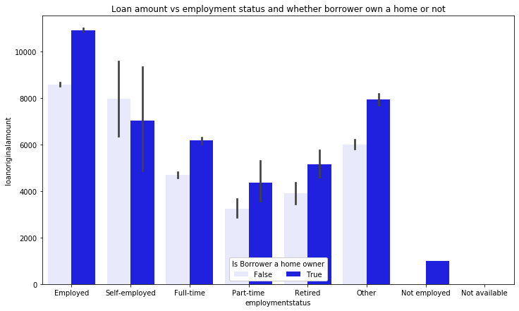

```python
plt.figure(figsize = [12, 7])
ax = sb.barplot(data =df, x= 'employmentstatus' , y= 'loanoriginalamount', hue = 'isborrowerhomeowner', color = 'b')
ax.legend(loc =8,ncol =3 , framealpha =1, title = 'Is Borrower a home owner')
plt.title('Loan amount vs employment status and whether borrower own a home or not');
```